# Varimax Pipeline

Compiled: Dec 23, 2021

Tutorial made by Delaram Pouyabahar. Please email d.pouyabahar@mail.utoronto.ca if you had any questions.

This notebook represents a workflow for running varimax-based factor analysis on a scRNA-seq dataset. We initially apply the varimax rotation to the scRNA-seq dataset, and then try to interpret the resulting factors to study the major axis of variance in the dataset. For this analysis, the normalized and scaled gene expression data and PCA loading matrix are required. Interpretation of the Varimax factors includes matching each factor with either a discrete or continuous covariate (metadata).

1. Discrete covariate: examples: cluster/cell-type, sex, strain, experimental condition, time points Method: Training a random forest model with the factors (cell x factor scores) as the design matrix and a covariate (cells x metadata-info) as the label. Correlation calculation based on the top genes associated with a covariate (ex: top marker genes of different cellular clusters). Cells are grouped based on the meta-data and the average expression of the selected genes is calculated. We then evaluate the correlation between the factor loadings and the average expression values.
2. Continuous covariate: examples: library-size, mt-percentage, pathway activation (calculated for each cell based on Ucell package) Method: usually a simple correlation between the factor and the covariate score for each cell (number of expressed genes in each cell of the dataset) should be sufficient.

Loading the required libraries:

```r
ipak <- function(pkg){
  new.pkg <- pkg[!(pkg %in% installed.packages()[, "Package"])]
  if (length(new.pkg))
    BiocManager::install(new.pkg, dependencies = TRUE)
  sapply(pkg, require, character.only = TRUE)
}


## loading required packages
Initialize <- function(){
  options(stringsAsFactors = FALSE)

  if (!requireNamespace("BiocManager", quietly = TRUE))
    install.packages("BiocManager")

  options(stringsAsFactors = FALSE)
  listOfPackages <- c('BiocManager', 'Seurat', 'randomForest', 'caTools', 'caret',
                      'viridis', 'org.Rn.eg.db', 'stringr',  'biomaRt',
                      'ggplot2', 'scClustViz', 'org.Hs.eg.db' ,'Matrix', 'devtools',
                      'DelayedArray', 'DelayedMatrixStats', 'stringr', 'pheatmap') #, 'celda' >> installation issue
  ipak(listOfPackages)

}

Initialize()
```

```
##        BiocManager             Seurat       randomForest            caTools
##               TRUE               TRUE               TRUE               TRUE
##              caret            viridis       org.Rn.eg.db            stringr
##               TRUE               TRUE               TRUE               TRUE
##            biomaRt            ggplot2         scClustViz       org.Hs.eg.db
##               TRUE               TRUE               TRUE               TRUE
##             Matrix           devtools       DelayedArray DelayedMatrixStats
##               TRUE               TRUE               TRUE               TRUE
##            stringr           pheatmap
##               TRUE               TRUE
```

Defining the required functions:

```r
get_varimax_rotated <- function(gene_exp_matrix, loading_matrix){

  ## gene_exp_matrix: gene expression matrix. rows named as genes and columns named as UMIs.
  ##                  attention: Data SHOULD be SCALED.
  ##                  Potentially gained from Seurat GetAssayData() function
  ## loading_matrix: the PCA loading matrix with rows named as gene names and
  ##                 columns named as PC numbers. Potentially gained from Seurat Loadings() function

  ######### Varimax rotation
  initial_data <- t(gene_exp_matrix[rownames(gene_exp_matrix) %in% rownames(loading_matrix),])

  ## apply varimax rotation on the loadings
  varimax_res <- varimax(loading_matrix)
  rotatedLoadings <- varimax_res$loadings
  ## calculating the PC scores matrix
  invLoadings     <- t(pracma::pinv(rotatedLoadings))
  scores          <- scale(initial_data) %*% invLoadings ## this second scaling is not necessary

  ## compacting the rotated loading and score matrices in a list
  rotated_data <- list(rotLoadings=rotatedLoadings, rotScores = scores)
  return(rotated_data)
}


getMatchedFactor_RF <- function(varimax_scores, metadata_vector){

  varimax_scores$metadata = metadata_vector

  ### splitting the train and test data
  sample = sample.split(varimax_scores$metadata, SplitRatio = .75)
  train = subset(varimax_scores, sample == TRUE)
  test = subset(varimax_scores, sample == FALSE)

  ### training the RF model
  RF_trained <- randomForest(metadata ~ . , data = train, importance = TRUE)
  RF_prediction = predict(RF_trained, newdata=test[,-ncol(test)])
  ### constructing the contingency table
  cm = table(label=test[,ncol(test)], prediction=RF_prediction)
  print('Contingency table of the trained random forest model:')
  print(cm)
  ## finding the feature importance values of the
  Feature_importance = varImpPlot(RF_trained,
                                  main = 'Feature importance values of the given factors\nfor prediction of the target covariate')

  Feature_importance = Feature_importance[order(rowMeans(Feature_importance), decreasing = T),]
  return(Feature_importance)
}


get_scaled_by_gene <- function(x){
  y <- scale(t(x), center = TRUE, scale = TRUE)
  y[is.nan(y)] <- 0
  y2 <- t(y)
  y2 <- as.data.frame(y2)
  return(y2)
}
```

Importing the data. In standard single-cell analysis pipelines, often the top variable genes are used for the PCA analysis. However, For the varimax function, we need to incorporate all the genes in the dataset. Here, we also import the dataset which includes only the variable genes to be used for later visualizations. The dataset includes 4 rat liver samples, two from the post-operative days (POD) 3 and 7. Each sample has been normalized individually and then merged to create an integrated dataset The merged dataset is scaled afterward. We then apply PCA to the scaled dataset and use the resulting loading matrix for varimax analysis.

```r
#### pre-procssed data including all the features
merged_samples_allFeat <- readRDS('/home/delaram/LiverTransplant/Objects/Integrated_Syngeneic_mt3_lib1500_all_features.rds')
#### pre-procssed data based on the highly variable features
merged_samples <- readRDS('/home/delaram/LiverTransplant/Objects/Integrated_Syngeneic_mt3_lib1500.rds')
head(merged_samples_allFeat$POD)
```

```
## XC116_POD3_AAACCCAAGTAGGATT-1 XC116_POD3_AAACCCAGTACGTACT-1
##                        "POD3"                        "POD3"
## XC116_POD3_AAACCCAGTTGCGGCT-1 XC116_POD3_AAACCCATCCATTCAT-1
##                        "POD3"                        "POD3"
## XC116_POD3_AAACGAAAGGAGCTGT-1 XC116_POD3_AAACGAAAGTGCACAG-1
##                        "POD3"                        "POD3"
```

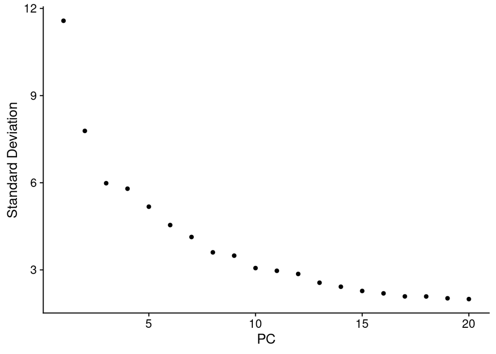

```r
merged_samples_allFeat$clusters <- paste0('c_', as.character(merged_samples$RNA_snn_res.0.5))

### Check the number of PCs to use
ElbowPlot(merged_samples, reduction = "pca")
```

```r
### needed data for the varimax PCA
loading_matrix = Loadings(merged_samples_allFeat, 'pca')
gene_exp_matrix = GetAssayData(merged_samples_allFeat)

### Apply the varimax rotation
rot_data <-  get_varimax_rotated(as.matrix(gene_exp_matrix), loading_matrix)


rotatedLoadings <- data.frame(sapply(1:ncol(rot_data$rotLoading), function(i)rot_data$rotLoading[,i]))
varimax_scores <- data.frame(rot_data$rotScores)

colnames(varimax_scores) = paste0('Var_', 1:ncol(varimax_scores))
colnames(rotatedLoadings) = paste0('Var_', 1:ncol(rotatedLoadings))
```

Here, we would like to identify the factors which are associated with the POD covariate. We train a random forest model with the factors as the design matrix and the “POD” information for each cell, as the labels. We then chose the high importance features of the model as the factor which has captured the variation based on POD.

```r
#strain_info = as.factor(sapply(strsplit(x = rownames(varimax_scores), '_'), '[[', 2))
POD_info = as.factor(merged_samples_allFeat$POD)
RF_results =  getMatchedFactor_RF(varimax_scores=varimax_scores, metadata_vector=POD_info)
```

```
## [1] "Contingency table of the trained random forest model:"
##       prediction
## label  POD3 POD7
##   POD3 1869    5
##   POD7    0 4272
```

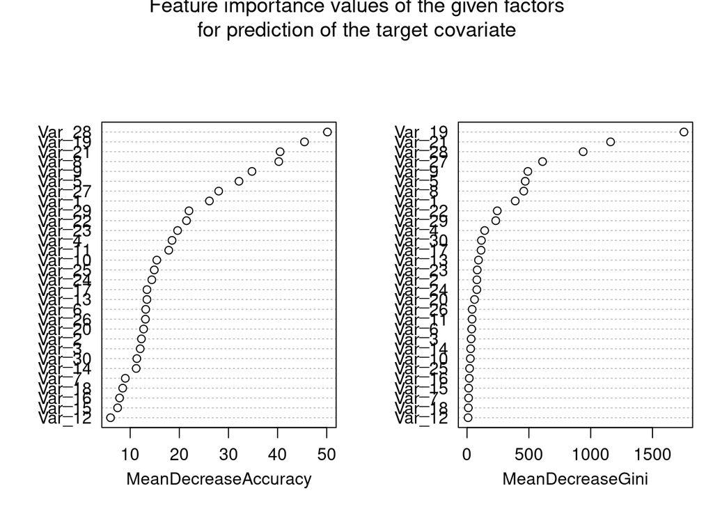

```r
RF_results = RF_results[order(rowMeans(RF_results), decreasing = T),]
```

Visualizing the top matched factor (Var_19 in this case)

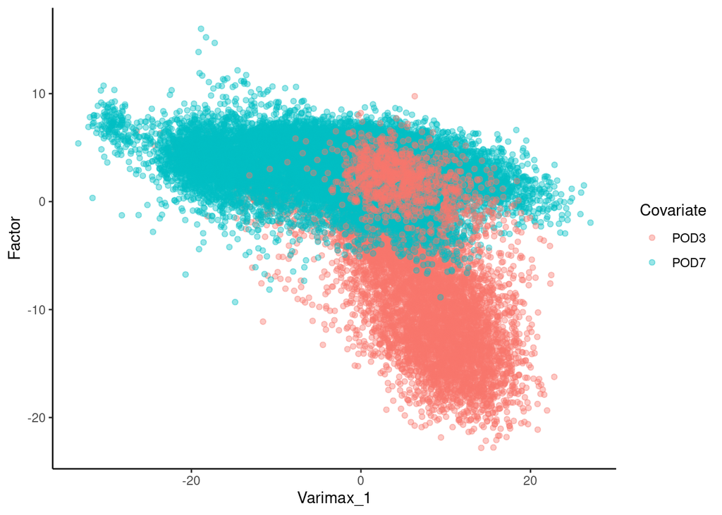

```r
### evaluating the best matched factor
i = 1
varimax_num = rownames(RF_results)[i]
df = data.frame(Varimax_1=varimax_scores[,1],
                Factor=varimax_scores[,varimax_num],
                Covariate=POD_info)

ggplot(df, aes(x=Varimax_1, y=Factor, color=Covariate))+geom_point(alpha=0.4)+theme_classic()
```

We can now look into the loading vector corresponding to varimax-19 and identify the genes which have the highest contribution. Based on our analysis, these genes indicate high variation between the POD 3 and 7. Based on the visualization, the positive values of this factor represent POD7 and the negative values represent POD3.

```r
var19_loading_df = data.frame(gene=rownames(rotatedLoadings),loading_value=rotatedLoadings[,varimax_num])
### soring the genes based on varimax-19 scores:
var19_loading_df = var19_loading_df[order(var19_loading_df$loading_value, decreasing = T),]

### genes associated with POD7
head(var19_loading_df)
```

```
##          gene loading_value
## 5873     Upp2    0.05196334
## 3203    Nceh1    0.04581859
## 9598      Ahr    0.04423994
## 14163 Sec14l3    0.04171708
## 10869   Sntb1    0.04149621
## 20867 Col18a1    0.04148137
```

```r
### genes associated with POD3
tail(var19_loading_df)
```

```
##                 gene loading_value
## 7466  AABR07048475.1   -0.07882482
## 11657        Angptl8   -0.08181835
## 7135           Clvs1   -0.08218057
## 7464       LOC259244   -0.09806392
## 14205            Gck   -0.11659991
## 7468  AABR07048482.1   -0.11689860
```

We then check if the selected factor (Var-19) seem to be specific to one cluster. It seems to be global in this case.

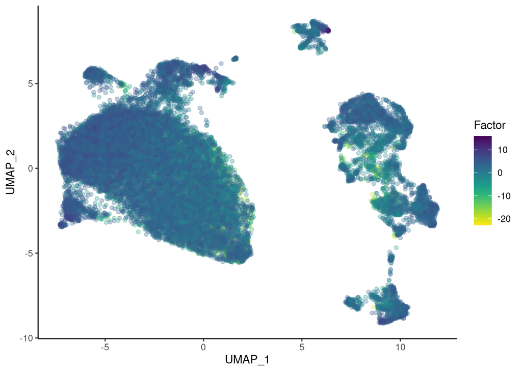

```r
merged_samples$cluster = merged_samples$RNA_snn_res.0.5

merged_samples = RunUMAP(merged_samples, reduction = "harmony", dims = 1:30)

umap_df = data.frame(Embeddings(merged_samples, 'umap'),
                     Factor=varimax_scores[,varimax_num],
                     Covariate=POD_info,
                     cluster=merged_samples$cluster)

ggplot(umap_df, aes(x=UMAP_1, y=UMAP_2, color=Factor))+geom_point(alpha=0.3)+theme_classic()+scale_color_viridis(direction = -1)
```

Finding the factors which represent the quality control covariates. Varimax-1 and 27 seem to capture the variance of library size, and varimax 8 and 29 represent the mitochondrial-gene percentage.

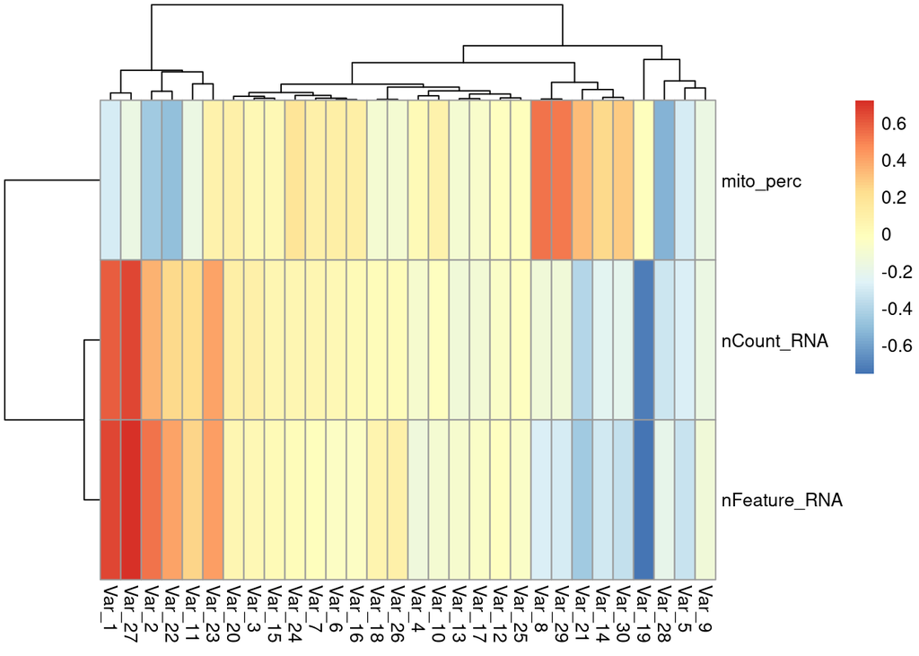

```r
df2 = data.frame(nCount_RNA=merged_samples$nCount_RNA,
                 nFeature_RNA=merged_samples$nFeature_RNA,
                 mito_perc=merged_samples$mito_perc,
                 varimax_scores)
pheatmap(cor(df2)[1:3, 4:ncol(cor(df2))])
```

```r
######################################
```

As described before, another way to find a matched factor with the covariate of interest (example: cluster/cell-type) is to calculate the correlation based on the top genes associated with a covariate (ex:cluster). Cells are grouped based on the meta-data and the average expression of the selected genes are calculated We then evaluate the correlation between the Factor loadings and the average expression values:

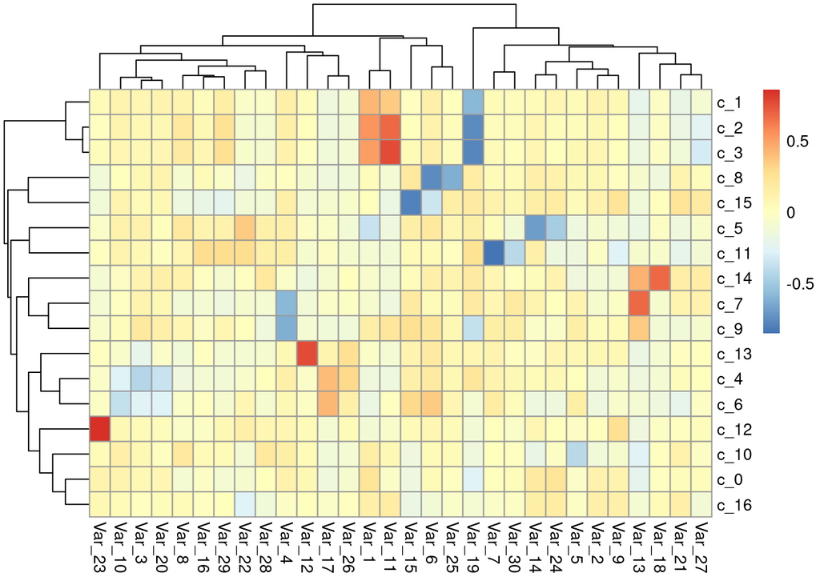

```r
merged_samples$cluster = merged_samples$RNA_snn_res.0.5
cluster_names_types = names(table(merged_samples$RNA_snn_res.0.5))
cluster_expression <- sapply(1:length(cluster_names_types), function(i){
  a_cluster_name = cluster_names_types[i]
  GetAssayData(merged_samples, 'data')[,merged_samples$cluster == a_cluster_name]
}, simplify = F)

names(cluster_expression) = cluster_names_types

## calculate the average expression of each gene in each cluster
cluster_average_exp <- lapply(cluster_expression, function(x){
  df = data.frame(average=rowSums(x)/ncol(x))
  return(df)
})

## Concatenate all the clusters together to make a matrix
cluster_average_exp_df = do.call(cbind,cluster_average_exp)
#colnames(cluster_average_exp_df) = paste0('cluster_',names(cluster_average_exp))
colnames(cluster_average_exp_df) = paste0('c_',names(cluster_average_exp))

## scale and center all the genes in the matrix
cluster_average_exp_df <- get_scaled_by_gene(cluster_average_exp_df) ## scaling over the clusters of interest

var_features = FindVariableFeatures(merged_samples, nfeatures = 200)
cluster_average_exp_df = cluster_average_exp_df[VariableFeatures(var_features),]

cluster_average_exp_df$gene = rownames(cluster_average_exp_df)


rotatedLoadings$gene = rownames(rotatedLoadings)

merged_df = merge(cluster_average_exp_df, rotatedLoadings, by.x='gene', by.y='gene')
merged_df = merged_df[,-1]
num_cluster = length(cluster_names_types)
merged_df.cor = cor(merged_df)
pheatmap(merged_df.cor[1:num_cluster,(num_cluster+1):ncol(merged_df.cor)])
```

Based on the heatmap, “cluster-13” seems to be highly correlated with “varimax-12”. We try to visualize varimax-12 on the UMAP and varimax scatterplot to see if they seem consistent or not.

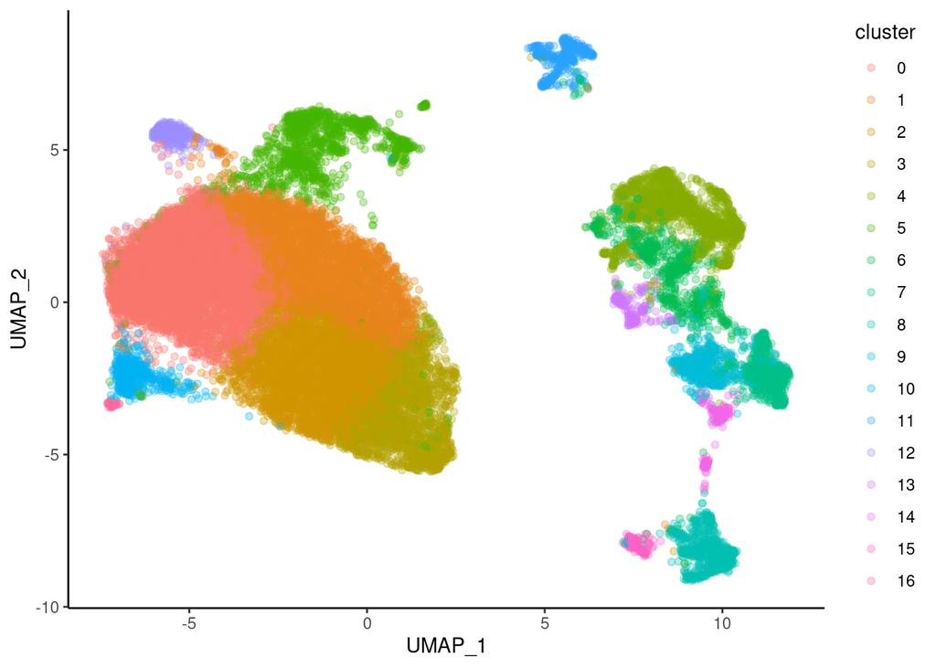

```r
umap_df = data.frame(Embeddings(merged_samples, 'umap'),
                     Varimax_1 = varimax_scores[,1],
                     Varimax_12=varimax_scores[,12],
                     Covariate=POD_info,
                     cluster=merged_samples$cluster)

ggplot(umap_df, aes(x=UMAP_1, y=UMAP_2, color=cluster))+geom_point(alpha=0.3)+theme_classic()
```

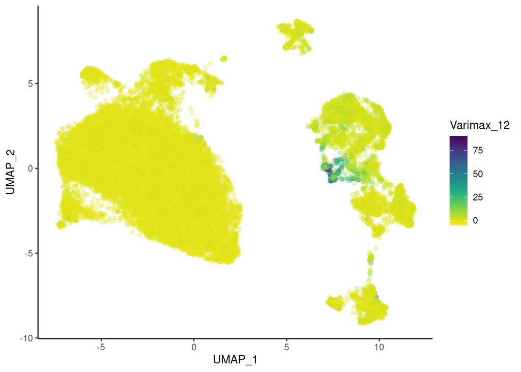

```r
ggplot(umap_df, aes(x=UMAP_1, y=UMAP_2, color=Varimax_12))+geom_point(alpha=0.3)+theme_classic()+scale_color_viridis(direction = -1)
```

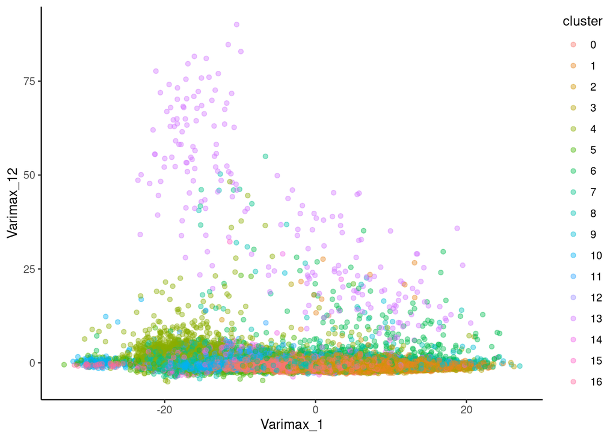

```r
ggplot(umap_df, aes(x=Varimax_1, y=Varimax_12, color=cluster))+geom_point(alpha=0.4)+theme_classic()
```

Now we can look at the corresponding loadings of varimax-12 and identify the genes which are associated with cluster-13

```r
var12_loading_df = data.frame(gene=rownames(rotatedLoadings),loading_value=rotatedLoadings[,12])
### soring the genes based on varimax-19 scores:
var12_loading_df = var12_loading_df[order(var12_loading_df$loading_value, decreasing = T),]

### genes associated with cluster 13
head(var12_loading_df)
```

```
##                 gene loading_value
## 16215          Skap1     0.1705501
## 16271          Ikzf3     0.1458629
## 14055           Clnk     0.1325829
## 16984 AABR07017902.1     0.1325076
## 14777          Cd247     0.1280483
## 16231          Tbx21     0.1275774
```